# Week1 Examples

Joy-El Talbot

5/27/2021

## Purpose

Show how we can calculate statistical distributions and solve Bluman problems in R.

*Adapted from D. Koloski’s ALY6010.23545-DKExamples-Week1.R*

*Includes problems from Bluman’s Elementary Statistics: a step-by-step approach, 10th edition*

```r
#library(ggplot2)
```

### R commands for standard normal distribution

#### Graphing Normal Distribution in R

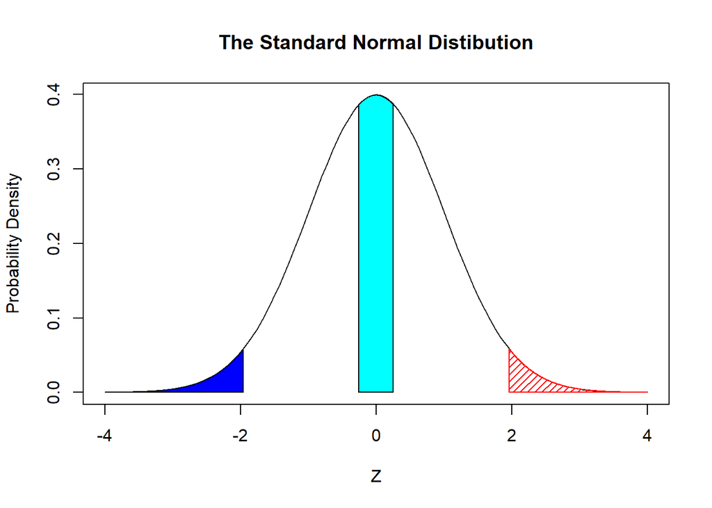

```r
# hat-tip to J.R. for their answer on Stackoverflow: https://stackoverflow.com/questions/27898931/how-to-shade-a-graph-using-curve-in-r
colorArea <- function(from, to, density, ..., col="blue", dens=NULL){
    y_seq <- seq(from, to, length.out=500)
    d <- c(0, density(y_seq, ...), 0)
    polygon(c(from, y_seq, to), d, col=col, density=dens)
}

curve(dnorm(x), from=-4, to=4,
  main = "The Standard Normal Distibution",
  ylab = "Probability Density",
  xlab = "Z")

colorArea(from=-4, to=qnorm(0.025), dnorm) # plot to left shading
colorArea(from=qnorm(0.975), to=4, dnorm, mean=0, sd=1, col=2, dens=20) # plot to right shading
colorArea(from=qnorm(0.4), to=qnorm(0.6), dnorm, col=5) # plot to middle shading
```

#### Calculating Z and P values

```r
?pnorm
```

```
## starting httpd help server ... done
```

> Problem 6.1.36 (Bluman, pg 323) Find probability using the standard normal distribution P(-0.20 < z < 1.56)

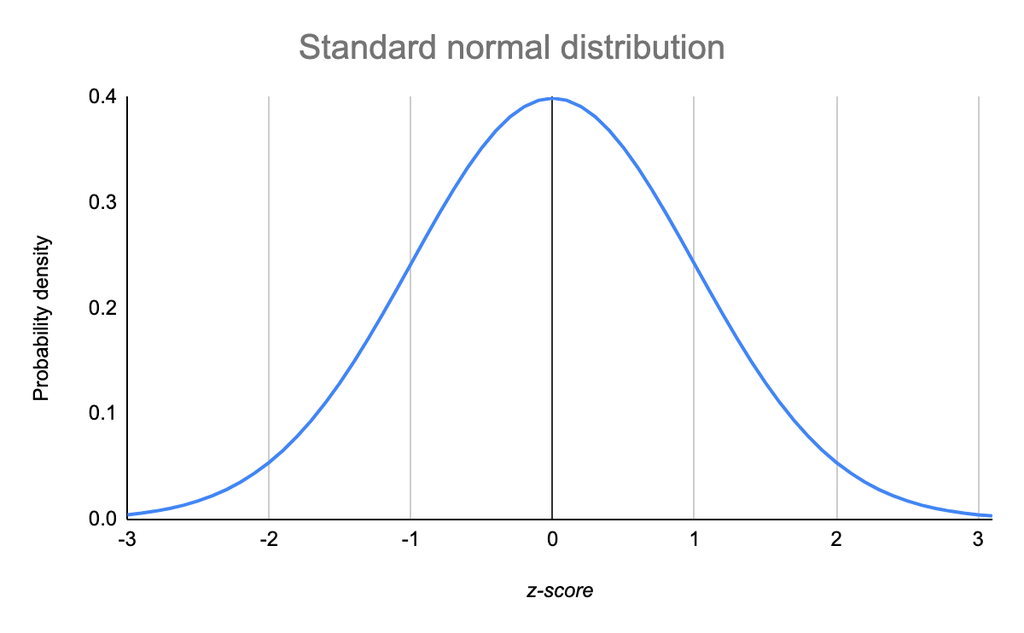

Estimate our shading from the Standard Normal Distribution

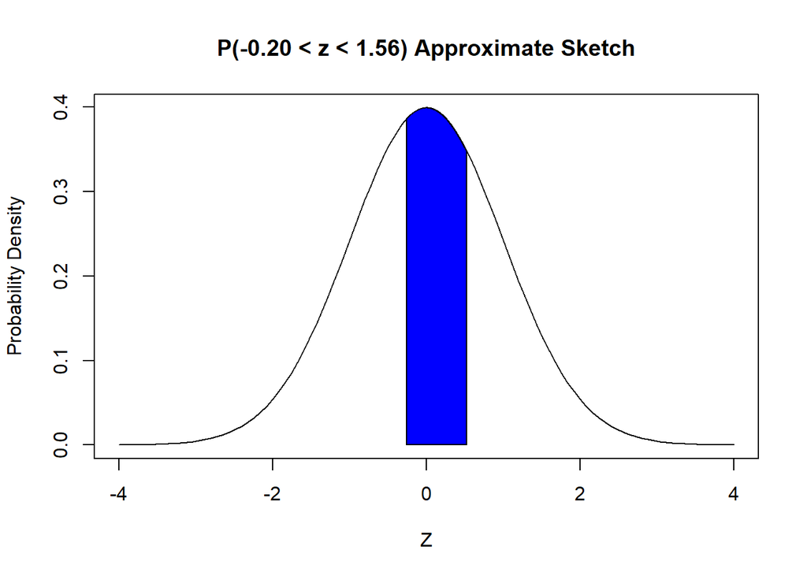

```r
curve(dnorm(x), from=-4, to=4,
  main = "P(-0.20 < z < 1.56) Approximate Sketch",
  ylab = "Probability Density",
  xlab = "Z")

colorArea(from=qnorm(0.4), # because 0.5 would be z=0, going a little lower for negative Z
          to=qnorm(0.7), # because 0.5 to 1 would cover 0 < z < 4, going a bit below mid-way (0.75)
          dnorm)
```

Or, given z, calculate p

```r
PvalHi <- pnorm(q = 1.56, mean = 0, sd = 1, lower.tail = TRUE)
PvalLo <- pnorm(q = -0.2) # shorten because defaults for mean, sd, and lower.tail are (0, 1, and TRUE, respectively)
pVal <- PvalHi - PvalLo
print(pVal)
```

```
## [1] 0.5198798
```

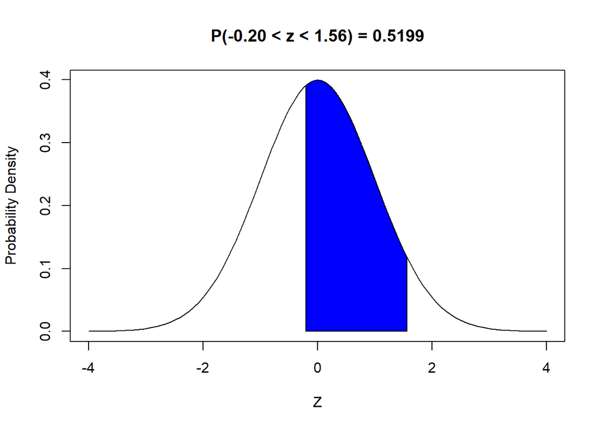

```r
curve(dnorm(x), from=-4, to=4,
  main = paste0("P(-0.20 < z < 1.56) = ", round(pVal,4)),
  ylab = "Probability Density",
  xlab = "Z")

colorArea(from=-0.2,
          to=1.56,
          dnorm)
```

> Problem 6.1.45 (Bluman, pg 323) Find the z-value for given area (aka p-value) P(X > z) = 0.0239

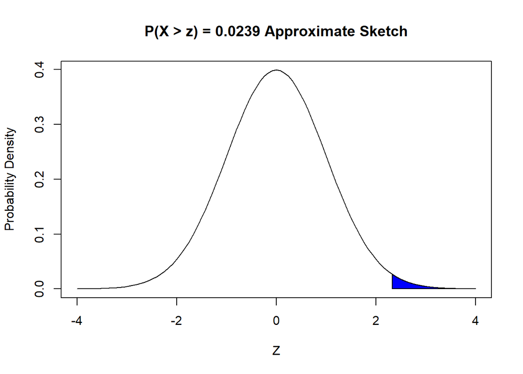

```r
curve(dnorm(x), from=-4, to=4,
  main = "P(X > z) = 0.0239 Approximate Sketch",
  ylab = "Probability Density",
  xlab = "Z")

colorArea(from=qnorm(0.99), # because the probability is very small
          to=4, # because it is a greater than
          dnorm)
```

Or, given p, calculate z

```r
z <- qnorm(p = 0.0239,
           mean = 0,
           sd = 1,
           lower.tail = FALSE) # because we are giving area to RIGHT of z
print(z)
```

```
## [1] 1.979142
```

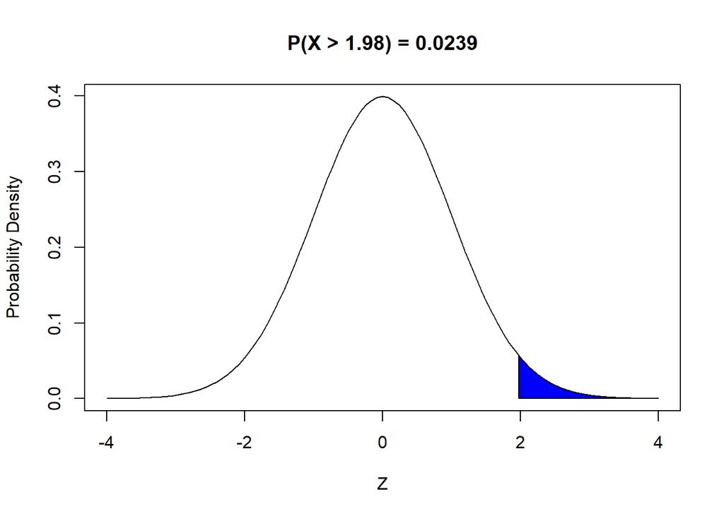

```r
curve(dnorm(x), from=-4, to=4,
  main = paste0("P(X > ", round(z, 2),") = 0.0239"),
  ylab = "Probability Density",
  xlab = "Z")

colorArea(from=z,
          to=4, # because it is a greater than problem
          dnorm)
```

> Problem 6.2.2a (Bluman, pg 337) Teachers’ Salaries The average annual salary for all US teachers is $47,750. Assume that the distribution is normal and the standard deviation is $5,680. Find the probability that a randomly selected teacher earns a. Between $35,000 and $45,000 a year

Step 1: Draw normal distribution curve and shade desired area.

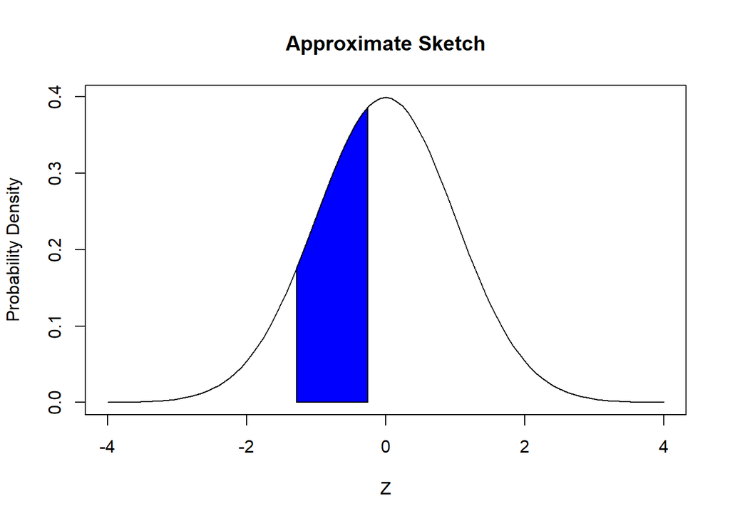

```r
curve(dnorm(x), from=-4, to=4,
  main = "Approximate Sketch",
  ylab = "Probability Density",
  xlab = "Z")

colorArea(from=qnorm(0.1),
          to=qnorm(0.4),
          dnorm)
```

Step 2: Find the z values

```r
mu <- 47750 # mean
sigma <- 5680 # stdev
# P(35000 < X < 45000) = ???  OR
xLo <- 35000
xHi <- 45000
zLo <- (xLo - mu) / sigma
zHi <- (xHi - mu) / sigma

# alternatively - we could write a function!
getZScore <- function(x, mu, sigma){
  return((x - mu) / sigma)
}

print("Comparing the calculation to the function, we get the same results.")
```

```
## [1] "Comparing the calculation to the function, we get the same results."
```

```r
print(paste("Original zLo: ", zLo, "  Function zLo: ", getZScore(xLo, mu, sigma)))
```

```
## [1] "Original zLo:  -2.24471830985915   Function zLo:  -2.24471830985915"
```

```r
print("However, order matters - getZScore(xLo, sigma, mu) gives different result")
```

```
## [1] "However, order matters - getZScore(xLo, sigma, mu) gives different result"
```

```r
print(paste("Original zLo: ", zLo, "  Function zLo: ", getZScore(xLo, sigma, mu)))
```

```
## [1] "Original zLo:  -2.24471830985915   Function zLo:  0.614031413612565"
```

```r
print("Unless you specify the parameter to argument matches:")
```

```
## [1] "Unless you specify the parameter to argument matches:"
```

```r
print("getZScore(xbar = xLo, sigma = sigma, mu = mu)")
```

```
## [1] "getZScore(xbar = xLo, sigma = sigma, mu = mu)"
```

```r
print(paste("Original zLo: ", zLo, "  Function zLo: ", getZScore(x = xLo, sigma = sigma, mu = mu)))
```

```
## [1] "Original zLo:  -2.24471830985915   Function zLo:  -2.24471830985915"
```

Step 3: Find the p-value given the z-scores

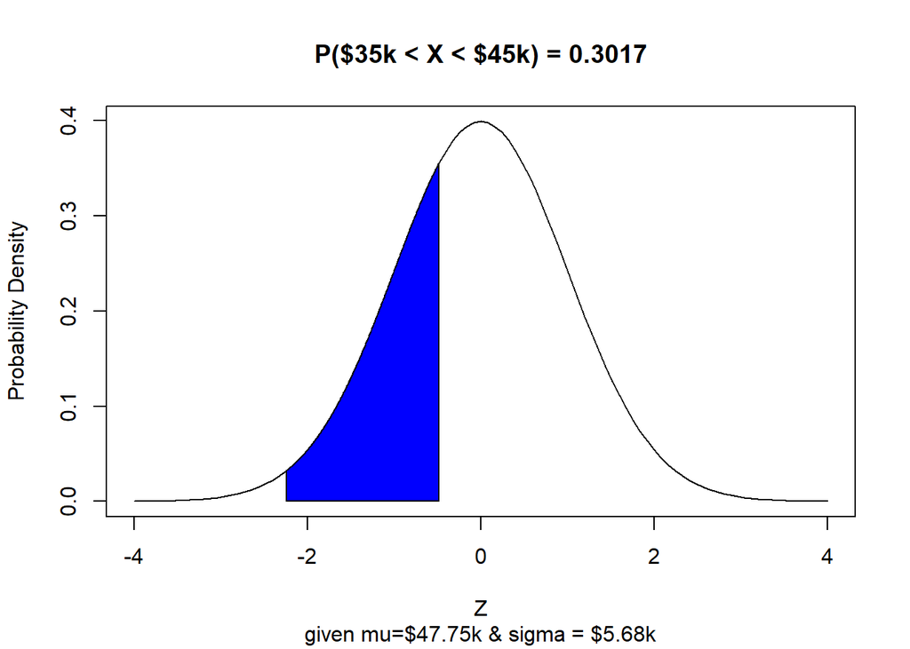

```r
# now like example 6.1.36 - given z get p
PvalLo <- pnorm(q = zLo)
PvalHi <- pnorm(q = zHi)
Pval <- PvalHi - PvalLo

# and plot
curve(dnorm(x), from=-4, to=4,
  main = paste0("P($35k < X < $45k) = ", round(Pval, 4)),
  sub = "given mu=$47.75k & sigma = $5.68k",
  ylab = "Probability Density",
  xlab = "Z")

colorArea(from=zLo,
          to=zHi, # because it is a greater than problem
          dnorm)
```

#### Applying the Central Limit Theorem

> As sample size n increases without limit, the shape of the distribution of the sample means taken with replacement from a population with mean mu and standard deviation sigma will approach a normal distribution with a mean mu and a standard deviation of sigma/sqrt(n) (Bluman, pg 346)

> Problem 6.3.22 (Bluman, pg 353) Systolic Blood Pressure Assume that the mean systolic blood pressure of normal adults is 120 millimeters of mercury (mm Hg) and the standard deviation is 5.6. Assume the variable is normally distributed. a. If an individual is selected, find the probability that the individual’s pressure will be between 120 and 121.8 mmHg. b. If a sample of 30 adults is randomly selected, find the probability that the sample mean [(xbar)] will be between 120 and 121.8 mmHg.

```r
# individual first
iLo <- getZScore(x=120, mu=120, sigma=5.6)
iHi <- getZScore(x=121.8, mu=120, sigma=5.6)
pValIndividual <- pnorm(iHi) - pnorm(iLo)

# sample group

# define the function for z-score when applying the central limit theorem about a central mean
# assumes n >= 30!
getSampleMeanZScore <- function(xbar, mu, sigma, n) {
  return((xbar - mu) / (sigma/sqrt(n)))
}

sLo <- getSampleMeanZScore(xbar=120, mu=120, sigma=5.6, n=30)
sHi <- getSampleMeanZScore(xbar=121.8, mu=120, sigma=5.6, n=30)
pValSample <- pnorm(sHi) - pnorm(sLo)

print(paste0("p-val for individual: ", round(pValIndividual, 4)))
```

```
## [1] "p-val for individual: 0.1261"
```

```r
print(paste0("p-val for sample: ", round(pValSample, 4)))
```

```
## [1] "p-val for sample: 0.4608"
```